# Patronage, Preference, and the Limits of School Choice in Irish Primary Education

Annual Education Research Summit · 5 November 2026

Damien Dupré, PhD

DCU Business School

Maedbh King, PhD

Education Equality

Simon Lewis

Education Equality

[figure not shown]

[figure not shown]

[figure not shown]

## The Patronage Landscape in Ireland

All schools are State-funded; each school’s patron sets its ethos

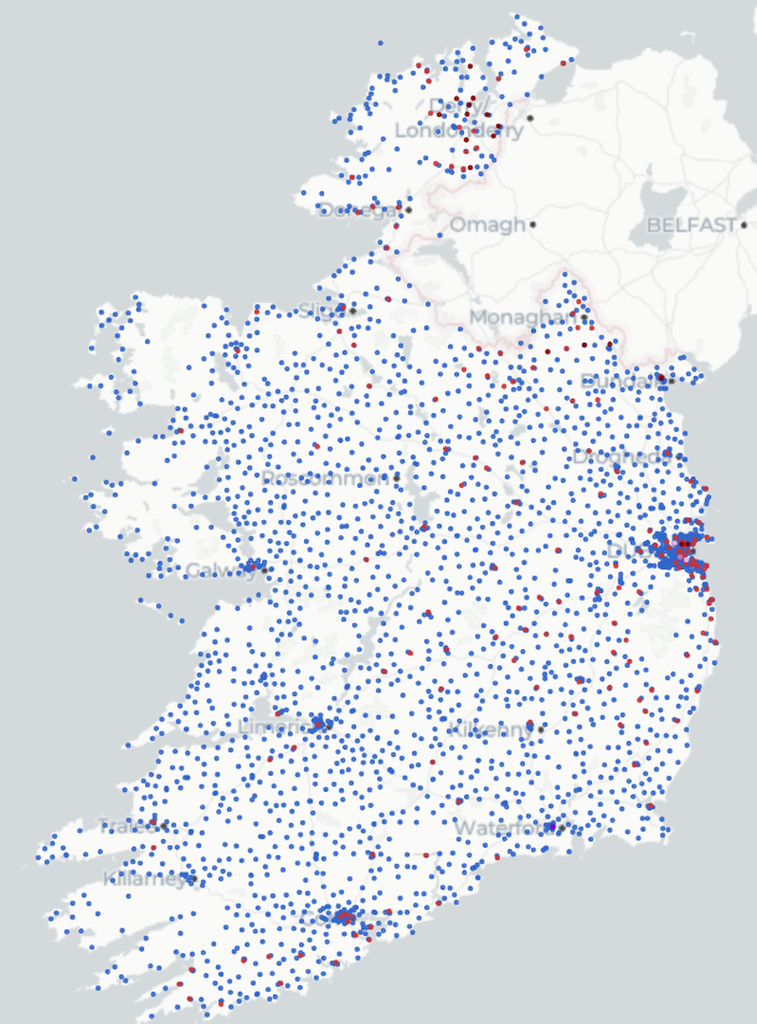

Denominational Catholic (blue); Church of Ireland and other faiths (red)

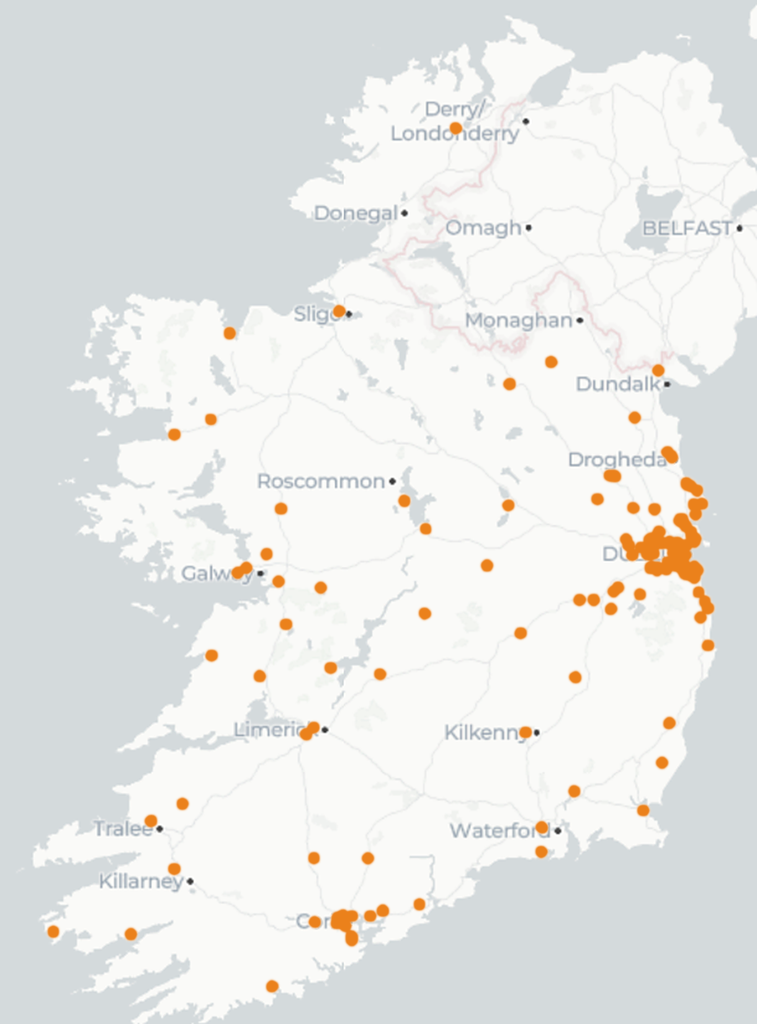

Multi-denominational

88.2% of schools have a Catholic patron 2,705 schools · 471,613 pupils (88.2% of pupils)

6.7% Church of Ireland and other faiths Presbyterian, Methodist, Jewish, Muslim, Quaker · 3.9% of pupils

5.1% are multi-denominational 156 schools · 41,995 pupils (7.9% of pupils)

Denominational ethos

- Faith formation in the patron’s religion during the school day
- Sacramental preparation in class time (Catholic schools)
- Ethos integrated across the school day; parents may opt children out of religious instruction

Multi-denominational ethos

- Ethics and values curriculum (e.g. *Learn Together*; *Goodness Me, Goodness You!*)
- Learning about religions and beliefs, not formation in one
- Faith formation, where offered, outside school hours or by belief groups

# The Primary School Survey

The largest consultation of parents in the history of the State

Described by the Department as “the largest of its kind ever undertaken in Ireland” (press release, 4 November 2025)

## The First of its Kind

What the Department set out to do

“Assess parental demand for different types of primary school provision”

Ethos · co-education or single-sex · English- or Irish-medium

Who was asked

- Parents of children **in** primary school and of children **not yet enrolled**
- One response per household, validated by Eircode
- Separately, school staff and boards of management

4 Nov 2025

Survey opens online

16 Dec 2025

Survey closes: 200,381 valid parent and 32,901 staff and board responses

7 Apr 2026

National parent results published

June 2026

Each school receives its own report. Summary report adds county results for parents and for staff and boards

Oct–Nov 2026

Boards decide whether to act on their results

Staff and board results are published nationally and by county, but not school by school, for privacy reasons

## The Survey in Numbers

Parents and guardians

Eligible 485,482

Responses received 49.7% of eligible 241,301

Valid responses 41.3% of eligible 200,381

Staff and boards of management

Eligible 84,285

Responses received 39.2% of eligible 32,999

Valid responses 39% of eligible 32,901

Parental response rates by county ran from **31.5%** (Louth) to **63.4%** (Meath).

Results Summary Report published by the Department of Education and Youth in June 2026. See https://www.gov.ie/en/department-of-education/campaigns/primary-school-survey/

# Communicated Results

## The Headline Figures

Parents and guardians, as published by the Department

45%

of **all** households prefer a **multi-denominational** ethos

40.2%

of households at **denominational** schools

40.7%

**demand for change**, incl. parents of future pupils

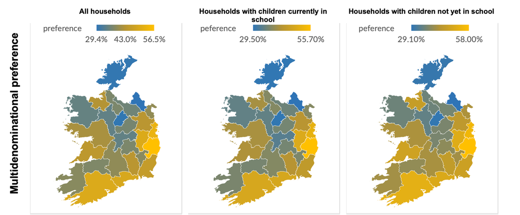

County averages, Results Summary Report (2026), Figure 4

National figures count **households**. Any change of patron is decided **one school at a time**.

## Staff and Boards of Management

Staff and board members, as published by the Department

34.7%

of all staff and board members prefer a multi-denominational ethos

**Parents: 45%**

31.6%

of those at denominational schools

**Parents: 40.2%**

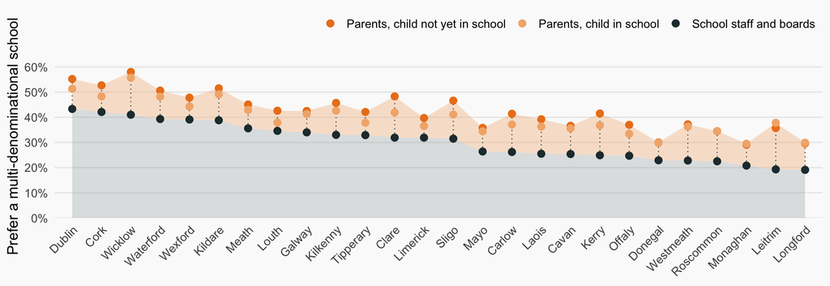

Share preferring a multi-denominational school, by county. Data: Results Summary Report (2026).

# Averages Hide Variability

What does 40% look like, school by school?

## Counties Differ, Schools Differ More

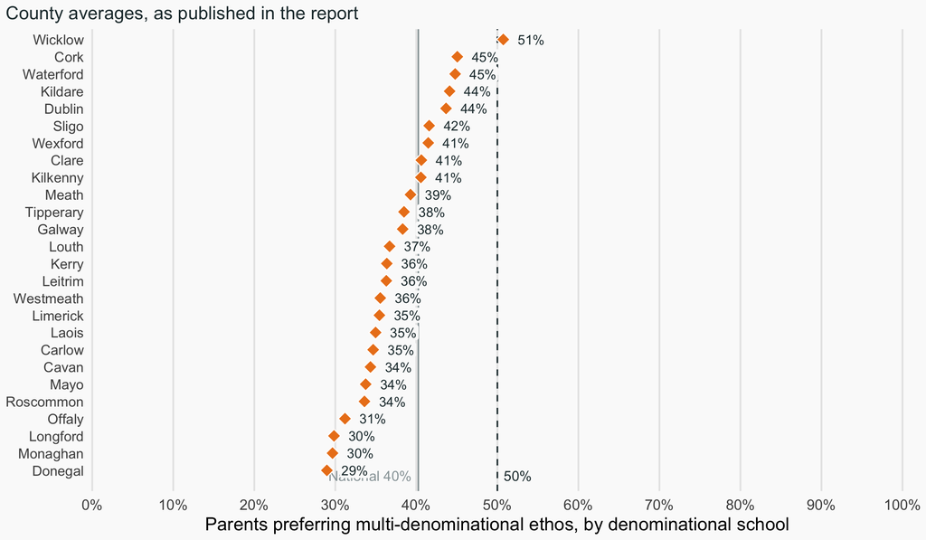

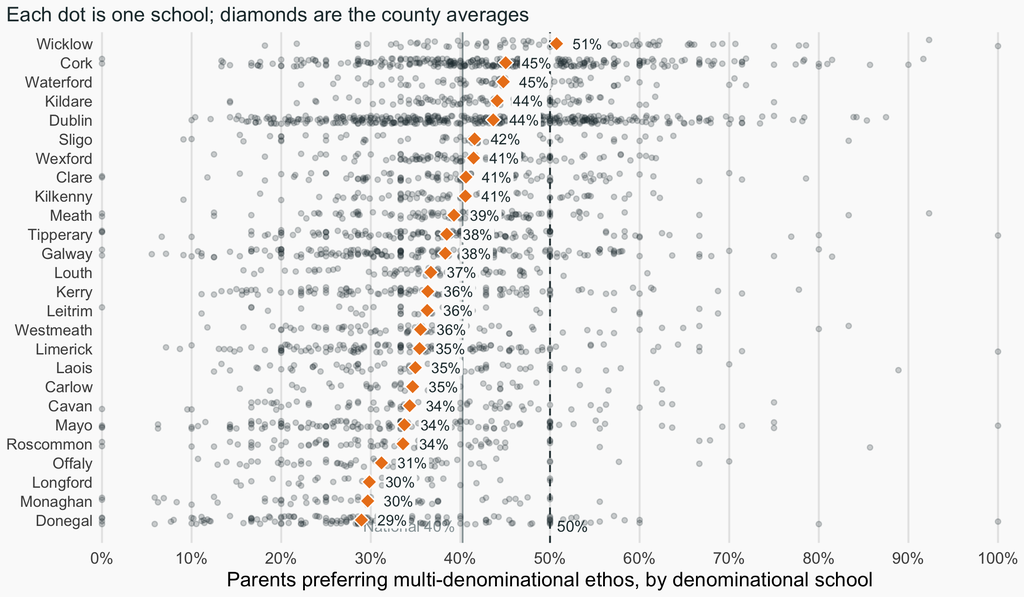

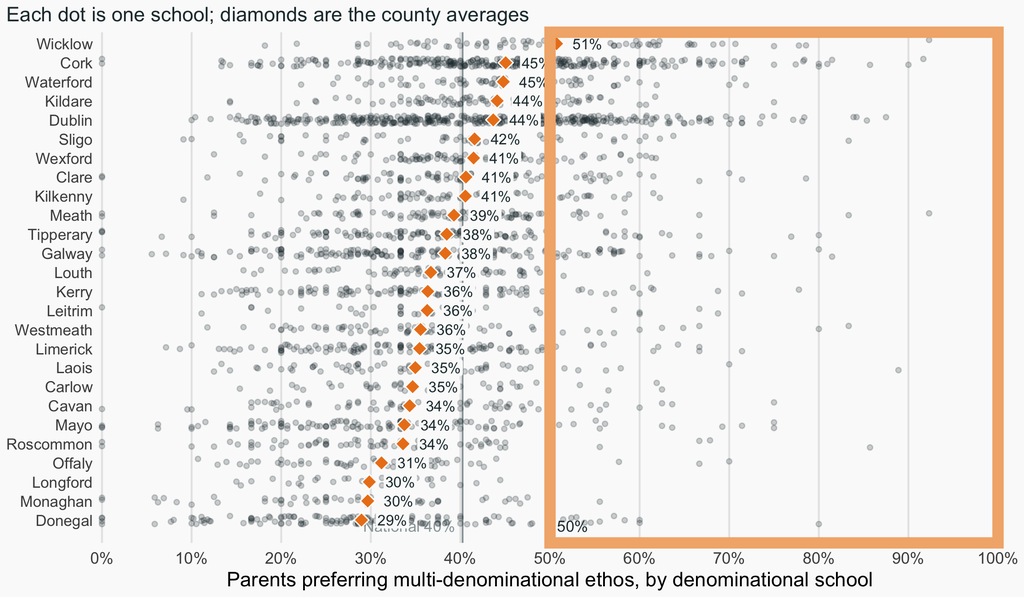

# What Counts as a Majority?

## How Many Schools Would Change?

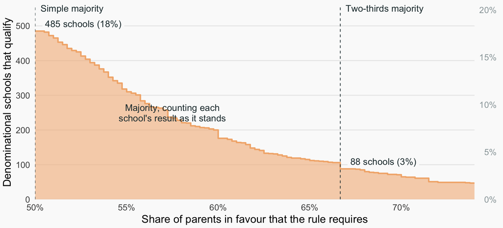

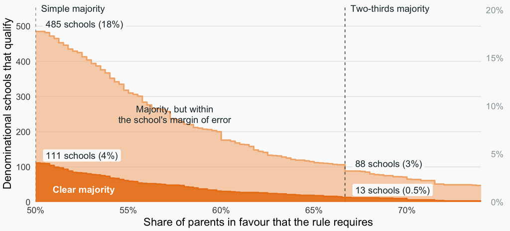

**18%** of schools are above 50%, but only **4.1%** once the margin of error is applied. **3.2%** are above two thirds, and **0.5%** once the error is applied.

## 4 Ways to Count a Majority

**Benchmark, Northern Ireland:** a **simple majority of votes cast** by parents starts a school’s move to integrated status; if fewer than half vote, a **second ballot** decides (1989 Order, Arts. 70 and 71). The Republic has **no rule**.

More than 50% of votes cast Referendums, Dáil votes, strike ballots

485 (18% of schools) 82 had half or more of households respond, NI’s first ballot; the other 403 would go to a second ballot

More than 50% (with the margin of error)

111 (4% of schools)

More than ⅔ of votes cast Impeaching the President

88 (3% of schools)

More than ⅔ (with the margin of error) The strictest reading

13 (0.5% of schools)

## Preference Far Exceeds Current Provision

Households that prefer a multi-denominational school 45%

Pupils in multi-denominational schools today 7.9%

Schools that are multi-denominational today 5.1%

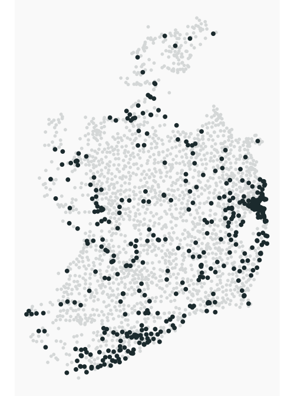

485

denominational schools where a majority of parents want a multi-denominational ethos

Parents of enrolled pupils, result as it stands

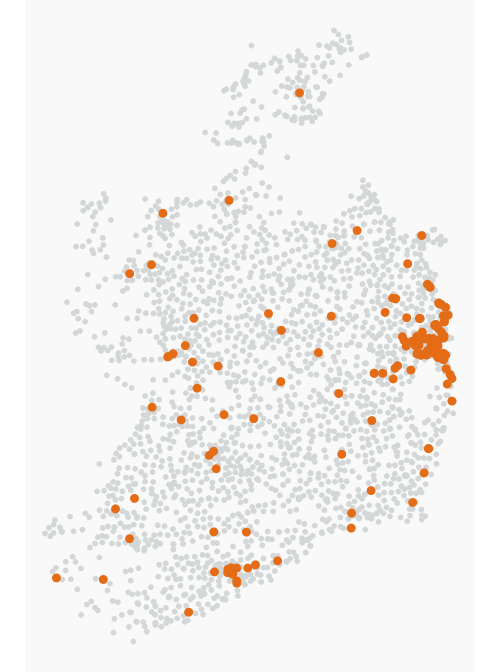

156

multi-denominational schools in the whole country today

## Summary and Next Steps

4 in 10

parents at denominational schools prefer a multi-denominational ethos

45% of all households

34.7%

of staff and boards prefer multi-denominational patronage, about 10 points below parents

Parents: 45%

42%

of parents heading for a denominational school would prefer a multi-denominational one

21,464 households

**Reconfiguration will reach few schools under any methodologically defensible threshold;** most families who want change will remain in denominational schools.

4 Jun 2026

Schools receive their reports

Sep–Oct

Boards consult their communities

31 Oct

Original opt-in deadline

5 Nov

We are here

30 Nov

Extended opt-in deadline

Sep 2027

First changes in schools

Data gaps, future research

- **Opted-out children:** no count of children opted out of faith formation in denominational schools, or of how that number is changing
- **Opt-out guidance:** promised in April 2026; “work is ongoing” (Oct 2026)

Closing thought

Should we build an education system for the majority, or for everyone?

## Thank You

**Damien Dupré** · DCU Business School

**Maedbh King** and **Simon Lewis** · Education Equality

[figure not shown]

Want to know what happens next? Follow Education Equality on Instagram @educationequalityireland Scan the code, or search the handle

*Every figure is computed from the published school file and the Results Summary Report.*